# BioLizardStyleR In Action

Robbe Neirynck

17-08-2023

# Introduction

In this guide, we’ll walk you through the installation of the `BioLizardStyleR` package and provide a brief overview of its functions using a practical example. The `BioLizardStyleR` package helps you make ggplot2 plots in the BioLizard style. It includes an integrated font installer, a dedicated ggplot2 theme, custom color functions, and a tool to add a BioLizard footer and export the plot.

# 1. Installation

To install the `BioLizardStyleR` package directly from GitHub, you will need to utilize the `devtools` package.

```r
if (!requireNamespace("devtools", quietly = TRUE)) {
  install.packages("devtools")
}

devtools::install_github("lizard-bio/nature-grade-visualization-playground", subdir="BioLizardStyleR", auth_token= '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
')
```

[output not shown]

[output not shown]

[output not shown]

[output not shown]

[output not shown]

[output not shown]

[output not shown]

```r
library(BioLizardStyleR)
```

**Note**: This package is private. You will require a Personal Access Token to access and install it. **Don’t use mine :)**

## Steps to Generate a Personal Access Token

1. **Access GitHub Settings**:
   - Click on your profile picture in the top-right corner.
   - Select “Settings”.
2. **Navigate to Developer Settings**:
   - On the left sidebar, select “Developer settings”.
3. **Access Personal Access Tokens**:
   - Click on “Personal access tokens”.
4. **Generate a New Token**:
   - Click “Generate new token”.
   - Provide a descriptive name for your token.
5. **Set Appropriate Permissions**:
   - Ensure you select the “repo” scope, which grants access to private repositories.

# 2. Installing the BioLizard font

1. **Check Local Installation:** First, verify if you have an Avenir font locally installed on your system.
2. **Using a Local Font:** If you already have an Avenir font:
   - Use the `pattern` argument in `install_biolizard_fonts()`.
   - Ideally, the `pattern` should be the name of the exact `.tff` file. However, in most cases, simply using ‘Avenir’ should suffice. The function should guide you in the process.
3. **Downloading and Installing from Github:**
   - If you don’t have the Avenir font locally:
     1. Download the font from the Github page of the package: [Nature Grade Visualization Playground](https://github.com/lizard-bio/nature-grade-visualization-playground/tree/main)
     2. Install the font on your system.
   - After installation, you can run `install_biolizard_fonts()` with the default settings.

Note that this installation is a one-time process and normally doesn’t need to be repeated in subsequent R sessions.

```r
#install_biolizard_fonts()
```

# 3. Crafting a BioLizard-Styled ggplot

Transforming your ggplot to match the BioLizard style involves a three-step process. Let’s illustrate this on a basic ggplots.

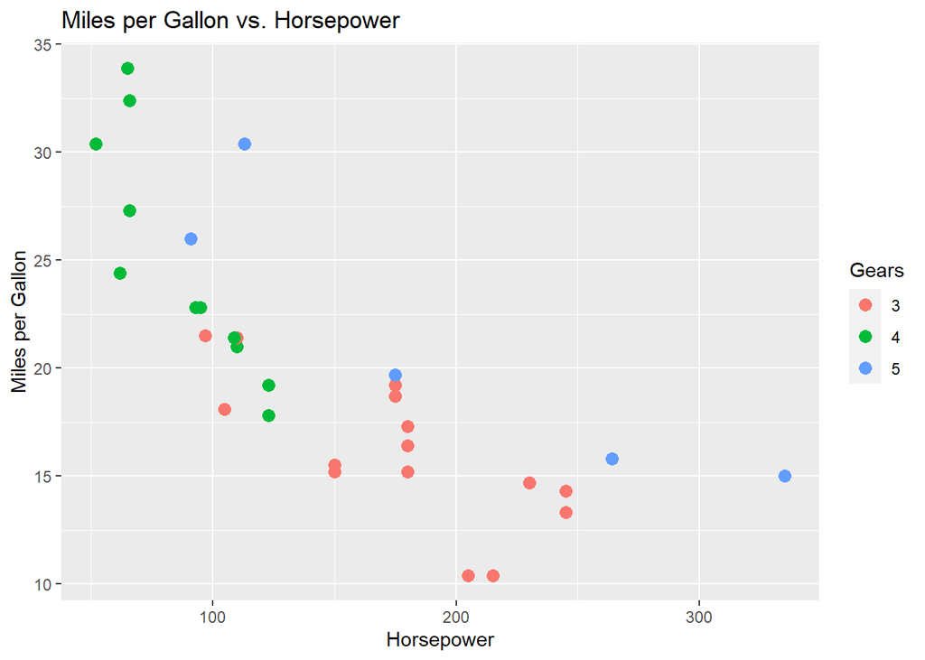

```r
library(ggplot2)
data("mtcars")
mtcars$gear <- as.factor(mtcars$gear)

testplot <- ggplot(data = mtcars, aes(x = hp, y = mpg)) +
              geom_point(aes(color = gear),size=3) +
              labs(title = "Miles per Gallon vs. Horsepower",
                   x = "Horsepower",
                   y = "Miles per Gallon",
                   color = "Gears")
testplot
```

## 3.1 Applying the Biolizard theme

In the initial step, we implement the biolizard theme through the **lizard_style()* function. This not only modifies various theme settings but also adjusts the font. An important note here is that the lizard theme can only act as a starting template! Depending on your specific plot, title length, variables in use, and other factors, you will need to make further theme adjustments.

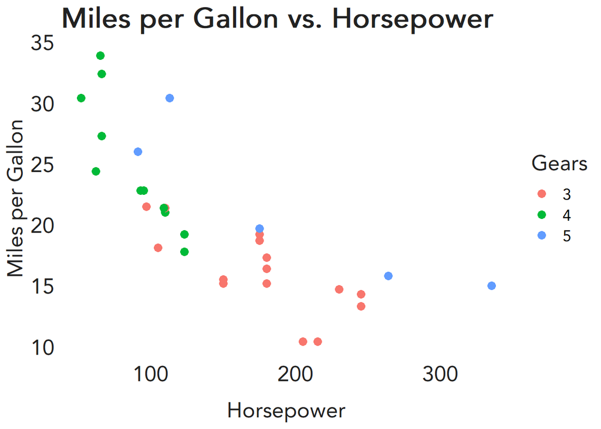

```r
testplot <- testplot + lizard_style()
testplot
```

## 3.2 Adding a BioLizard color palette

Once you’ve styled your plot, you can enhance it with a ‘BioLizard’ color palette. You have the option to choose from qualitative, sequential, or divergent palettes tailored for either discrete or continuous variables. These palettes incorporate the distinct hues of the BioLizard house colors, while ensuring they are color-blind friendly and perceptually uniform. For a deeper understanding of each palette, it’s recommended to consult the documentation for the respective function.

The coloring functions within the package adhere to a consistent naming convention: **scale__biolizard**. For the qualitative palette, only the discrete option is available, as it is the only logical choice in this context.

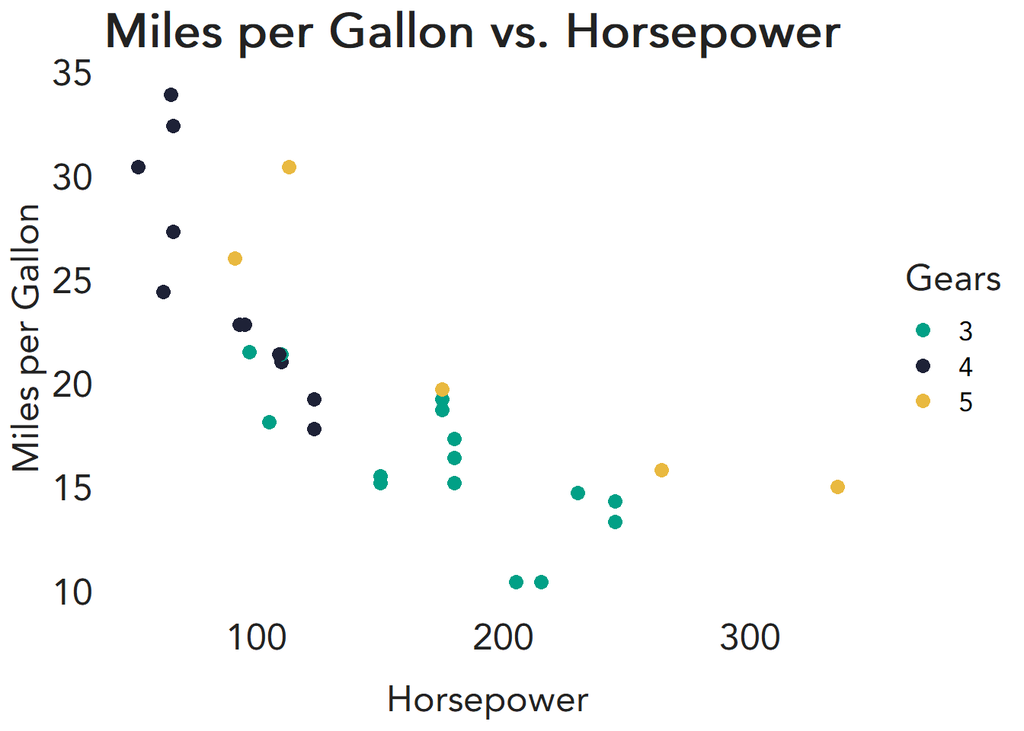

```r
testplot <- testplot + scale_color_qualitative_biolizard()
testplot
```

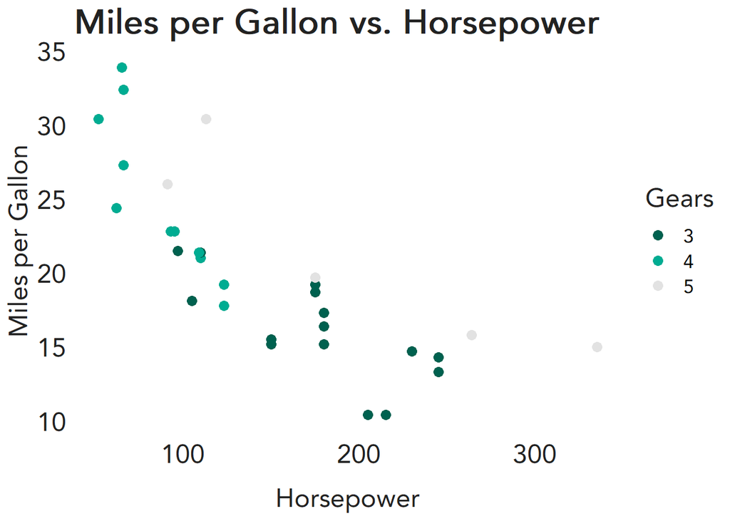

```r
testplotsequential <- testplot + scale_color_sequential_discrete_biolizard()
testplotsequential
```

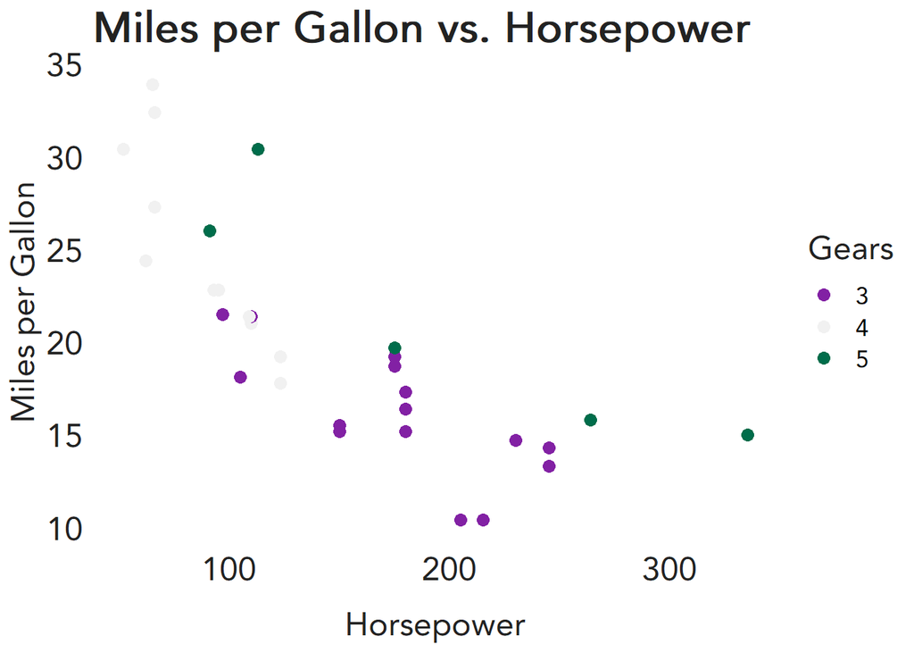

```r
testplotdivergent <- testplot + scale_color_divergent_discrete_biolizard()
testplotdivergent
```

## 3.3 Adding a BioLizard footer and exporting the plot.

For a unique touch on your visualizations, integrate a BioLizard footer using the **finalise_lizardplot()** function. This function not only positions the logo neatly at the bottom right but also provides an option to specify your data source directly in the footer, offering an alternative to the caption section of ggplot. When ready to export, either assign a name to your plot using `output_name` or specify a directory with `save_filepath`. The `device` argument allows to choose from the file types “png” (default), “pdf”, “svg”, or “ps”.

[figure not shown]

```r
finalise_lizardplot(testplot,source='Source: The mtcars dataset')
```